# EDA - Primer Pase

# Exploración de Datos

## Exploración de datos inicial

### Valores ausentes

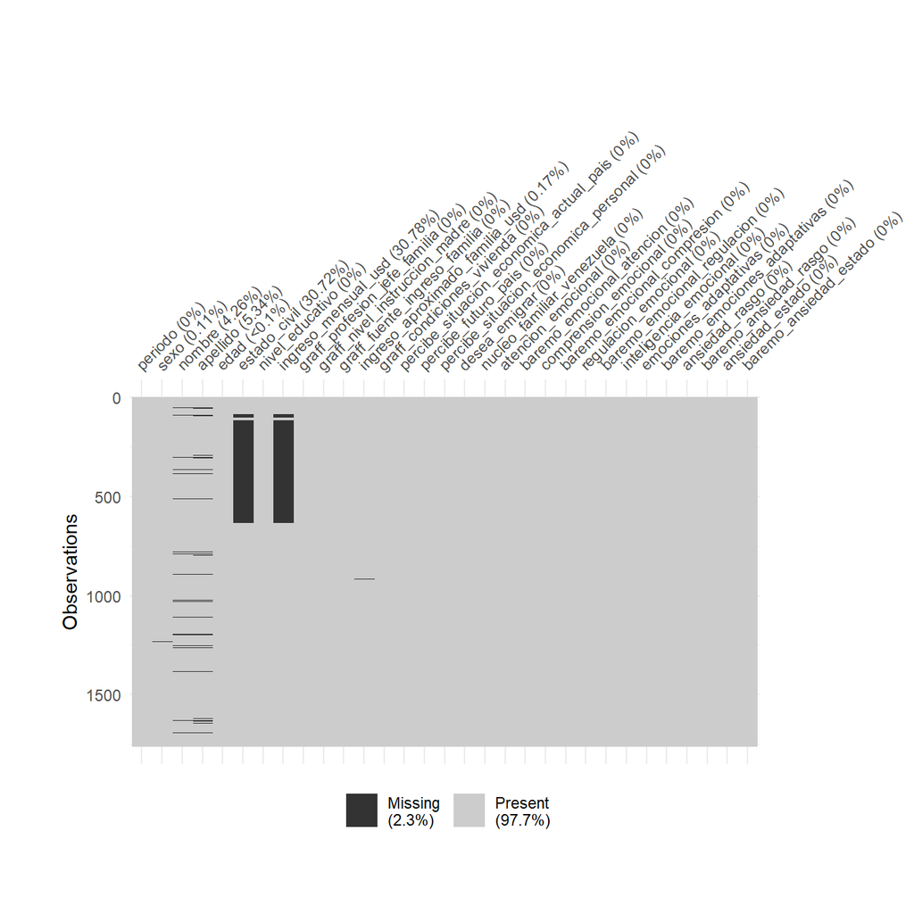

```r
# Cantidad de Valores Nulos según columna
df_congreso %>%
  vis_miss() +
  theme(axis.text.x = element_text(angle = 45)) +
  theme(plot.margin = unit(c(2, 3, 1.5, 1.2), "cm"))
```

### Outliers

Variables que se ven más afectadas por outliers:

- `ingreso_aproximado_familia_usd`
- `ingreso_mensual_usd`
- `ansiedad_rasgo`
- `emociones_adaptativas`
- `ansiedad_estado`
- `regulacion_emocional`

```r
# Seleccionar variables numericas para encontrar outliers univariados
df_congreso_numeric_vars <- df_congreso %>%
  select_if(is.numeric)


# Explorar que columnas tienen una mayor cantidad de outliers
outliers_univariate <- dlookr::diagnose_outlier(df_congreso)

outliers_univariate <- outliers_univariate %>%
  arrange(desc(outliers_cnt)) %>%
  filter(outliers_cnt > 1)


df_congreso[outliers_univariate$variables] %>%
  summary()
```

```
##  ingreso_aproximado_familia_usd ingreso_mensual_usd ansiedad_rasgo
##  Min.   :-5.000e+00             Min.   :       0    Min.   :-2.39201
##  1st Qu.: 1.500e+02             1st Qu.:      28    1st Qu.:-0.43796
##  Median : 5.000e+02             Median :     100    Median :-0.03223
##  Mean   : 1.547e+31             Mean   :   42987    Mean   : 0.00000
##  3rd Qu.: 2.000e+03             3rd Qu.:     400    3rd Qu.: 0.40349
##  Max.   : 2.719e+34             Max.   :40000000    Max.   : 2.58652
##  NA's   :3                      NA's   :542
##  emociones_adaptativas ansiedad_estado    regulacion_emocional
##  Min.   :-2.377436     Min.   :-3.74383   Min.   :-2.53710
##  1st Qu.:-0.395902     1st Qu.:-0.77479   1st Qu.:-0.49885
##  Median :-0.008554     Median :-0.03049   Median : 0.01941
##  Mean   : 0.011104     Mean   : 0.00000   Mean   : 0.00000
##  3rd Qu.: 0.381395     3rd Qu.: 0.80680   3rd Qu.: 0.51883
##  Max.   : 2.590284     Max.   : 3.78894   Max.   : 2.10408
##
```

#### Outliers por variable:

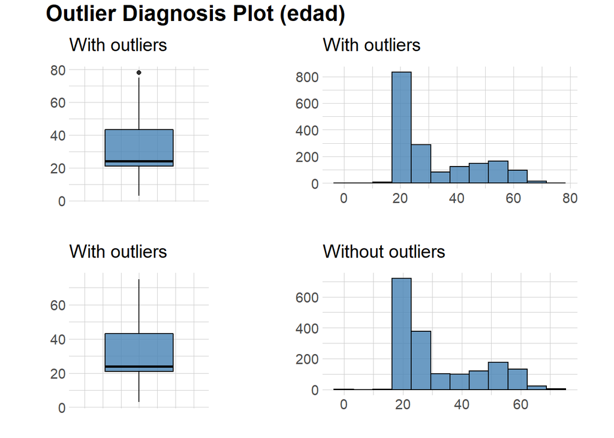

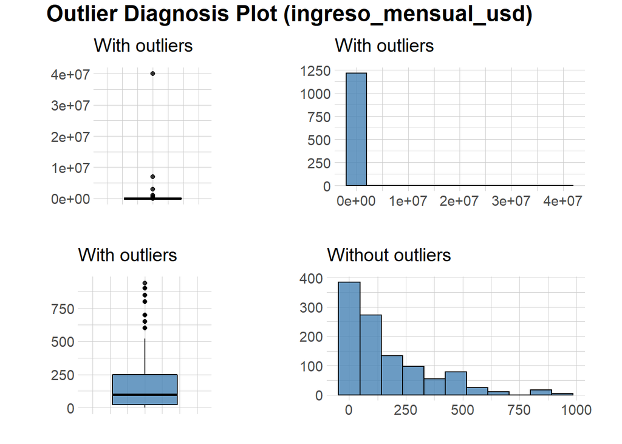

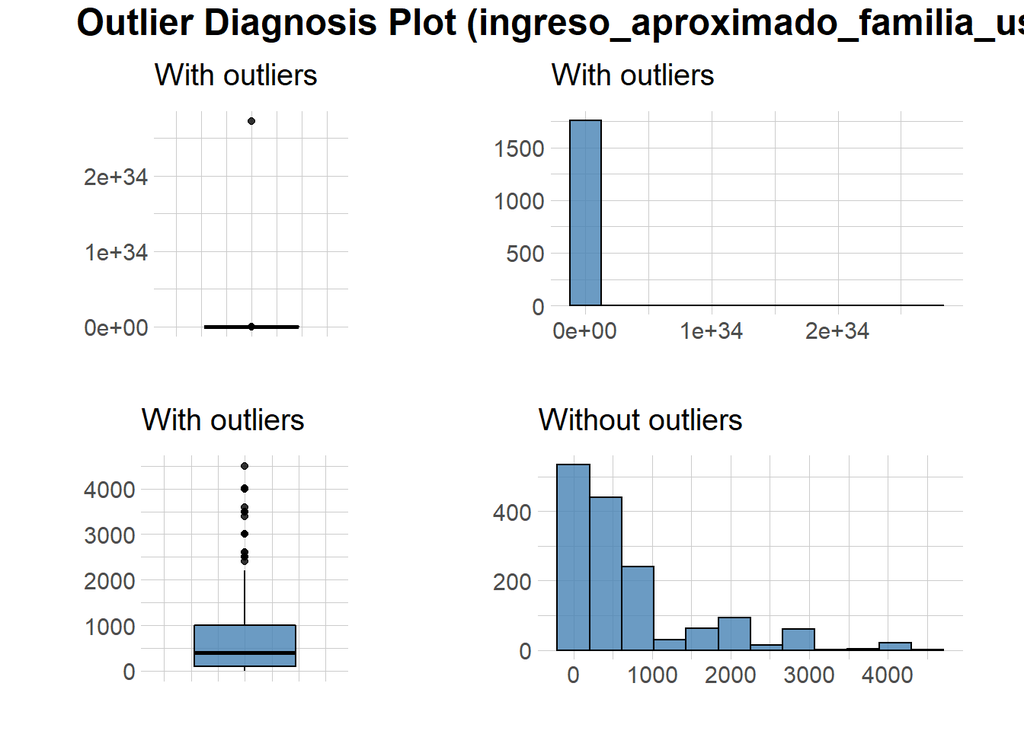

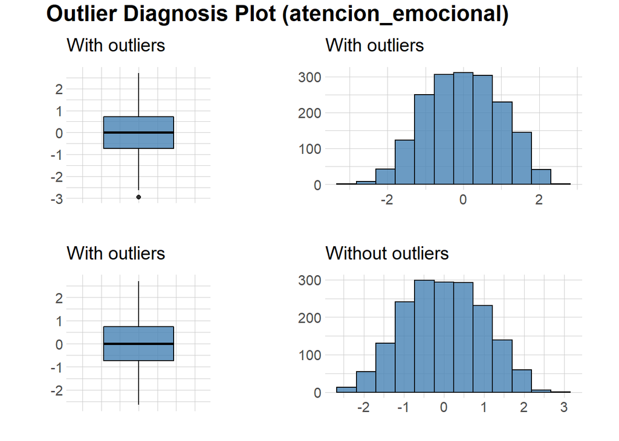

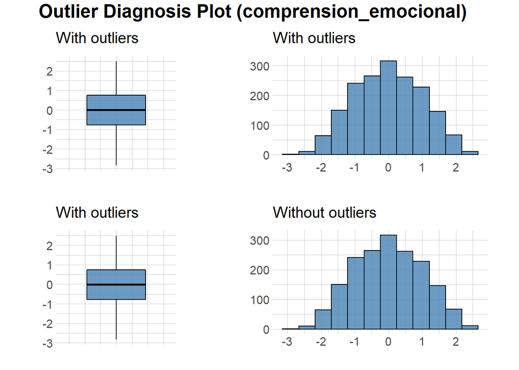

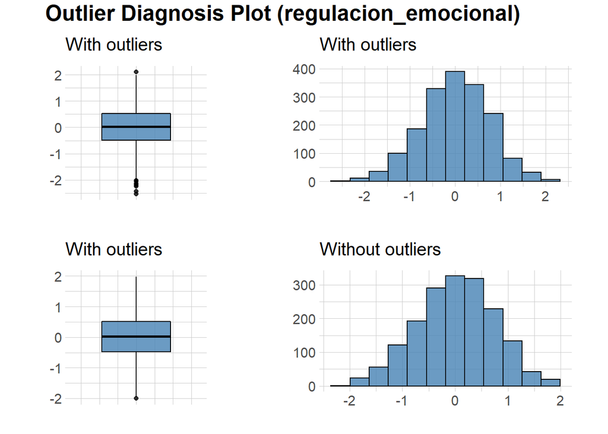

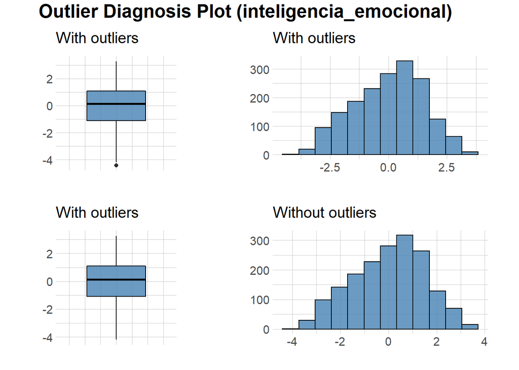

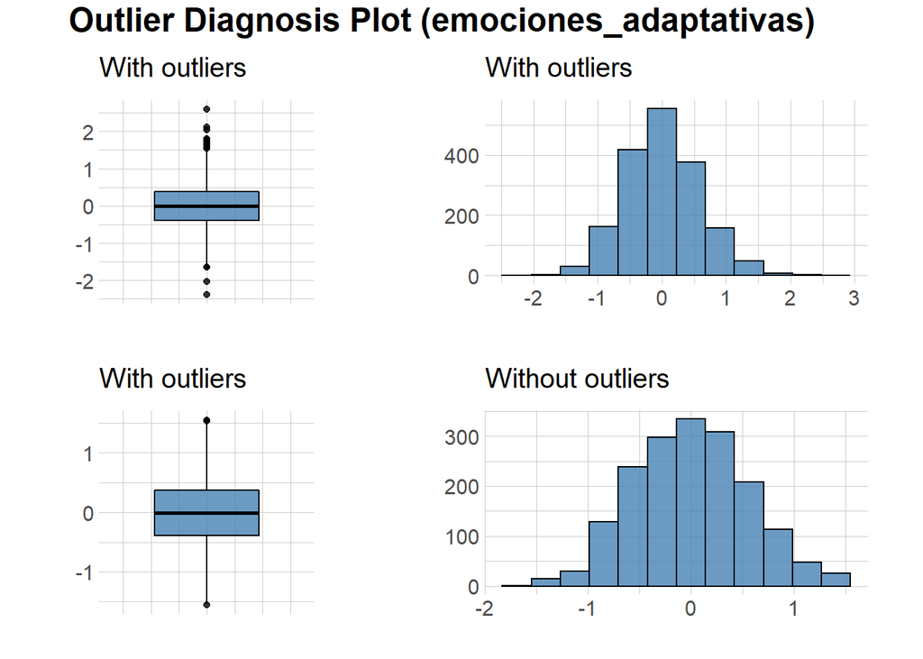

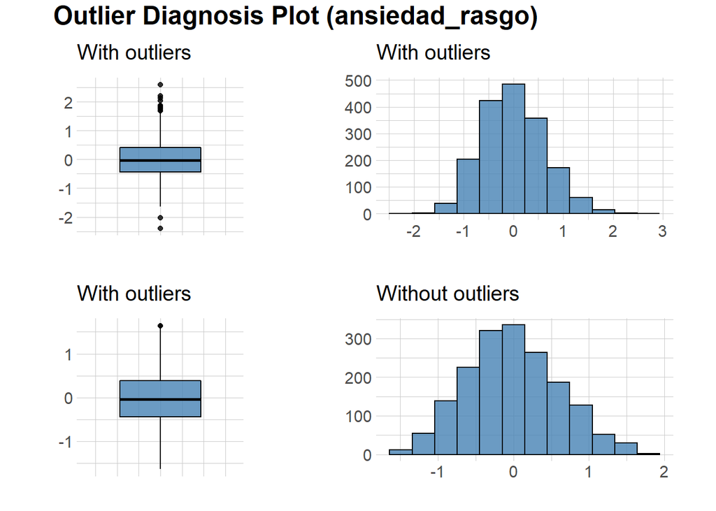

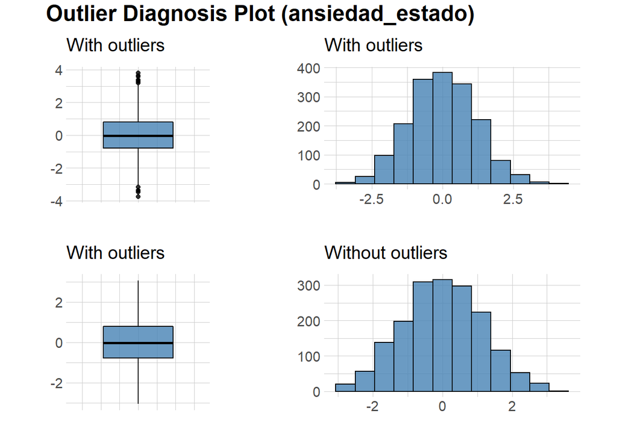

```r
df_congreso %>%
  dlookr::plot_outlier()
```

```r
get_outlier_threshold <- function(dataframe, variable_name) {
  q1 <- quantile(dataframe[[variable_name]], 0.25, names = FALSE, na.rm = TRUE) # Cuartil 1
  q3 <- quantile(dataframe[[variable_name]], 0.75, names = FALSE, na.rm = TRUE) # Cuartil 2

  iqr <- q3 - q1 # Rango Intercuartil

  low_bound_threshold <- q1 - 1.5 * iqr # Threshold para valores muy pequeños
  hi_bound_threshold <- q3 + 1.5 * iqr # Threshold para valores muy grandes


  return(c(low_bound_threshold, hi_bound_threshold))
}


# Detectar los thresholds para outliers
out_ingreso_familiar_thresh <- get_outlier_threshold(df_congreso, "ingreso_aproximado_familia_usd")
out_ingreso_mensual_thresh <- get_outlier_threshold(df_congreso, "ingreso_mensual_usd")

## Verificando que estoy haciendo subset de los valores correctos

# df_congreso %>%
#   filter(ingreso_aproximado_familia_usd > out_ingreso_familiar_thresh[2]) %>%
#   select(ingreso_aproximado_familia_usd)
#
# df_congreso %>%
#   filter(ingreso_mensual_usd > out_ingreso_mensual_thresh[2]) %>%
#   select(ingreso_mensual_usd) %>%
#   arrange(desc(ingreso_mensual_usd))


# Reeemplazar dichos valores con NA
df_congreso_clean <- df_congreso %>%
  mutate(ingreso_aproximado_familia_usd = ifelse(ingreso_aproximado_familia_usd > out_ingreso_familiar_thresh[2], NA, ingreso_aproximado_familia_usd))

df_congreso_clean <- df_congreso %>%
  mutate(ingreso_aproximado_familia_usd = ifelse(ingreso_mensual_usd > out_ingreso_mensual_thresh[2], NA, ingreso_mensual_usd))
```

## Análisis descriptivo univariante

## Supuestos

```r
shapiro.test(df_congreso_clean$ansiedad_estado)
```

```
##
##  Shapiro-Wilk normality test
##
## data:  df_congreso_clean$ansiedad_estado
## W = 0.99914, p-value = 0.6009
```

## Comparación de Medias

### Período

El período únicamente tiene una relación estadísticamente significativa con la `ansiedad_estado` y `regulacion_emocional`. **No** continuaré analizando el `período` como ha sido segmentado en la data recolectada.

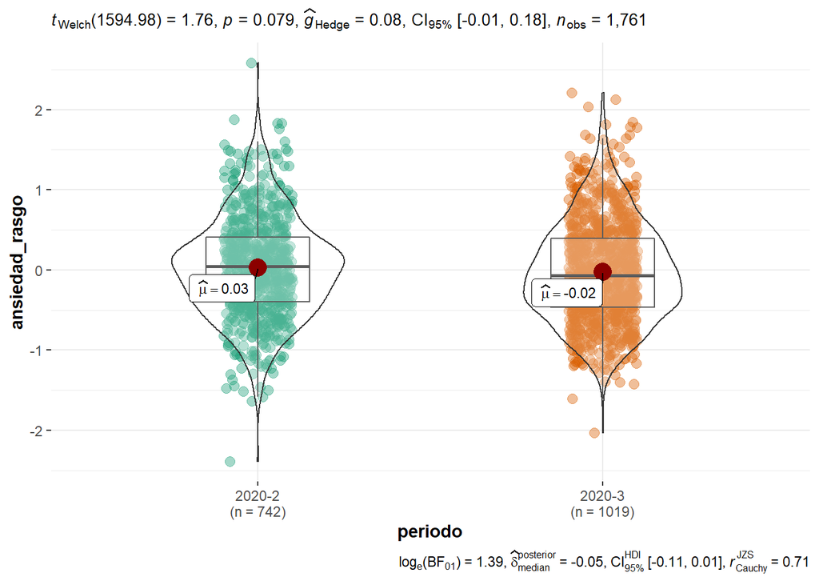

```r
df_congreso_clean %>%
  ggbetweenstats(x = periodo, y = ansiedad_rasgo)
```

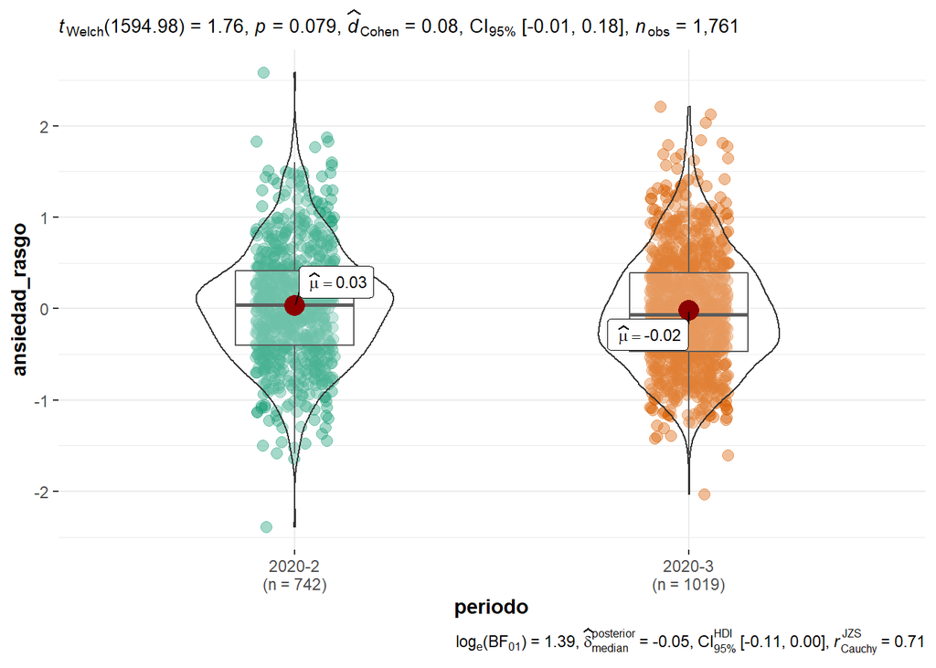

```r
df_congreso_clean %>%
  ggbetweenstats(x = periodo, y = ansiedad_rasgo, effsize.type = "eta")
```

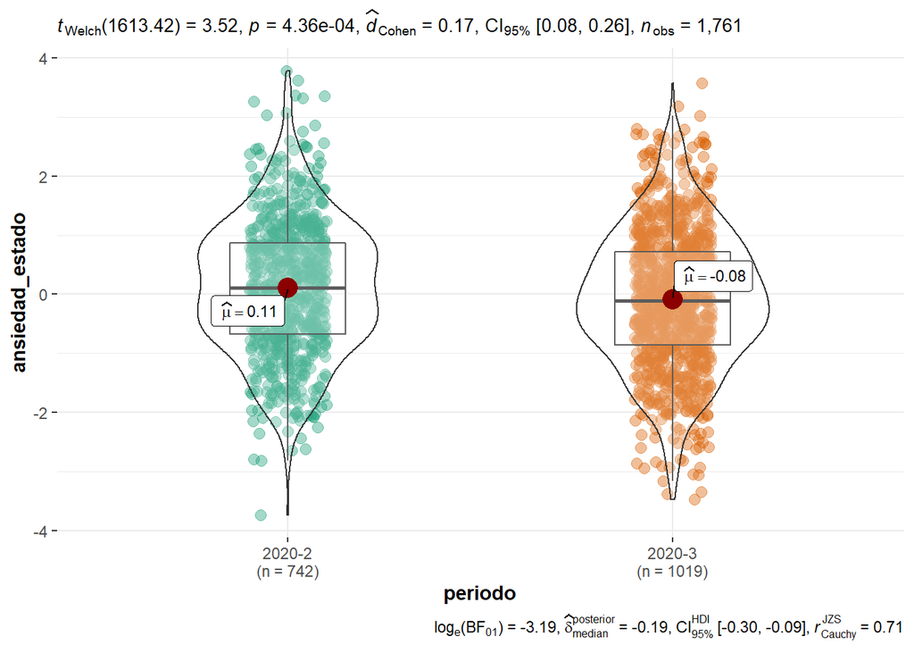

```r
df_congreso_clean %>%
  ggbetweenstats(x = periodo, y = ansiedad_estado, effsize.type = "eta")
```

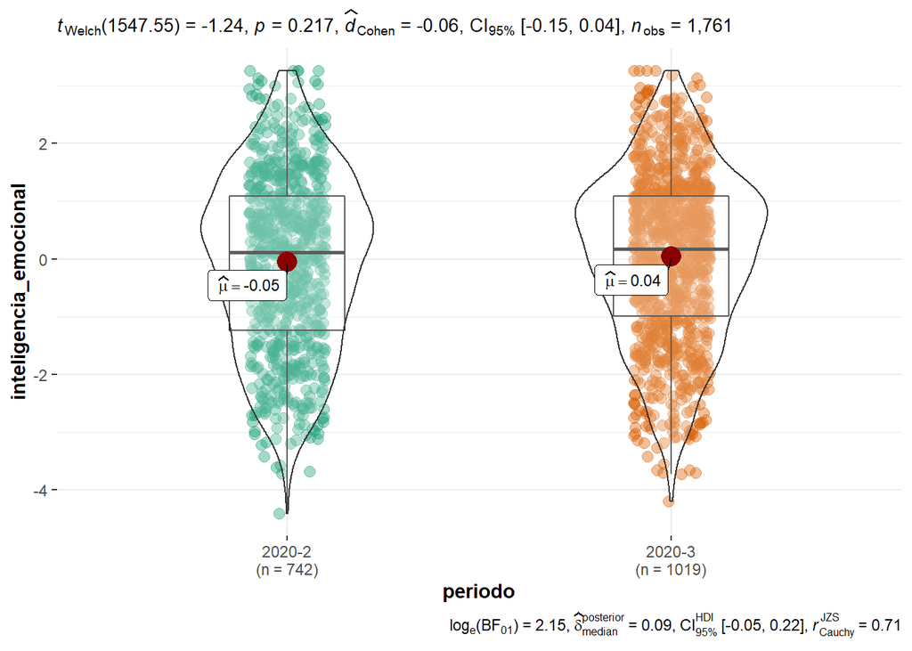

```r
df_congreso_clean %>%
  ggbetweenstats(x = periodo, y = inteligencia_emocional, effsize.type = "eta")
```

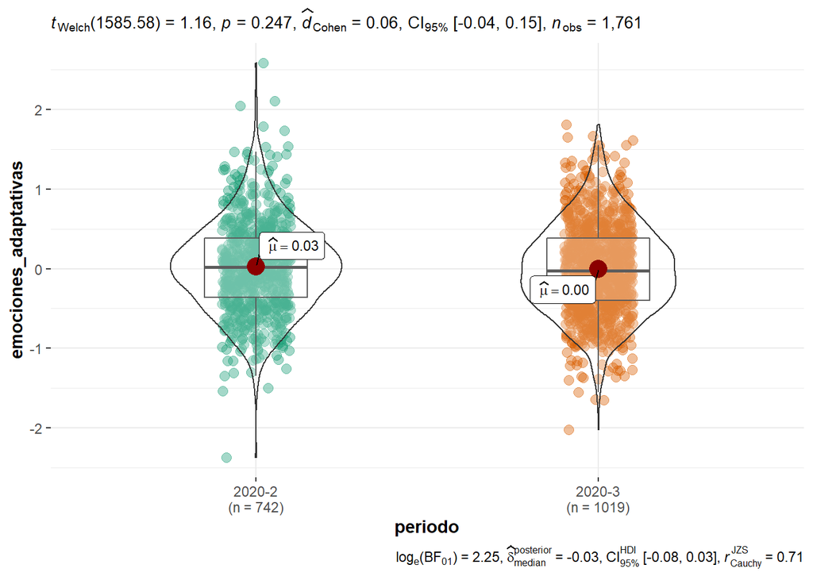

```r
df_congreso_clean %>%
  ggbetweenstats(x = periodo, y = emociones_adaptativas, effsize.type = "eta")
```

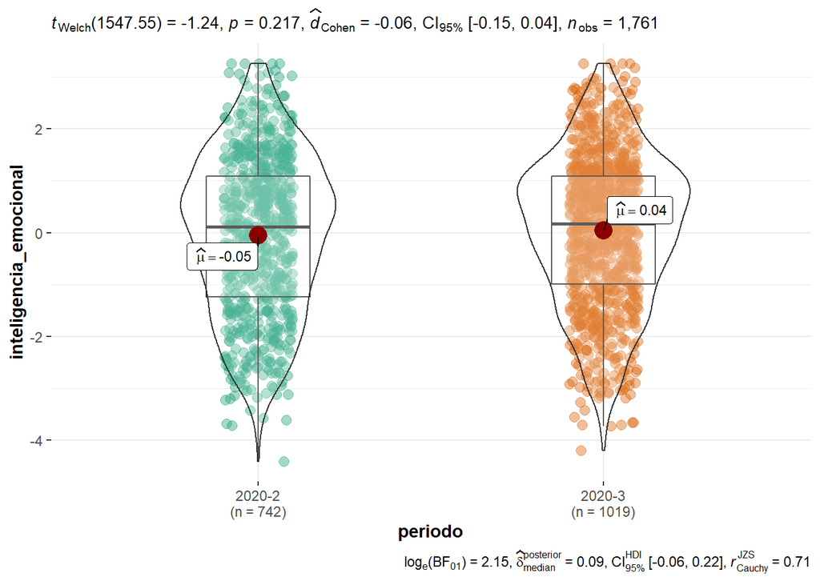

```r
df_congreso_clean %>%
  ggbetweenstats(x = periodo, y = inteligencia_emocional, effsize.type = "eta")
```

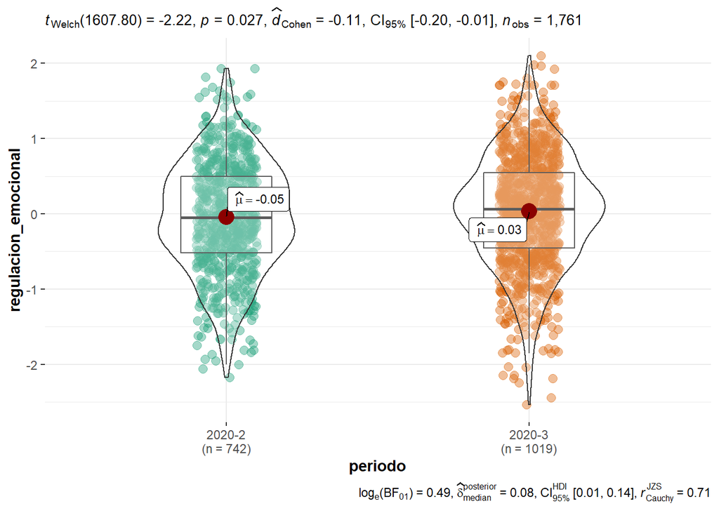

```r
df_congreso_clean %>%
  ggbetweenstats(x = periodo, y = regulacion_emocional, effsize.type = "eta")
```

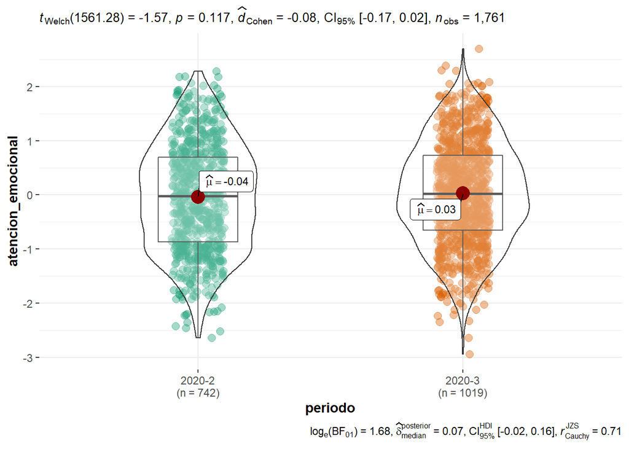

```r
df_congreso_clean %>%
  ggbetweenstats(x = periodo, y = atencion_emocional, effsize.type = "eta")
```

### VI: Variables Baremo VD: Ansiedad

- `braemo_emociones_adaptativas` tiene `p valor` sumamente bajo y un eta cuadrado parcial fuerte.
  - Posibles problemas:
  - Los grupos `baremo_emociones_adaptativas` no están equitativamente distribuidos.

```r
for (element in baremo_colnames[1:5]) {
  print(df_congreso_clean %>%
    ggbetweenstats(
      x = !!element,
      y = ansiedad_estado,
      effsize.type = "eta",
      na.rm = TRUE
    ))
}
```

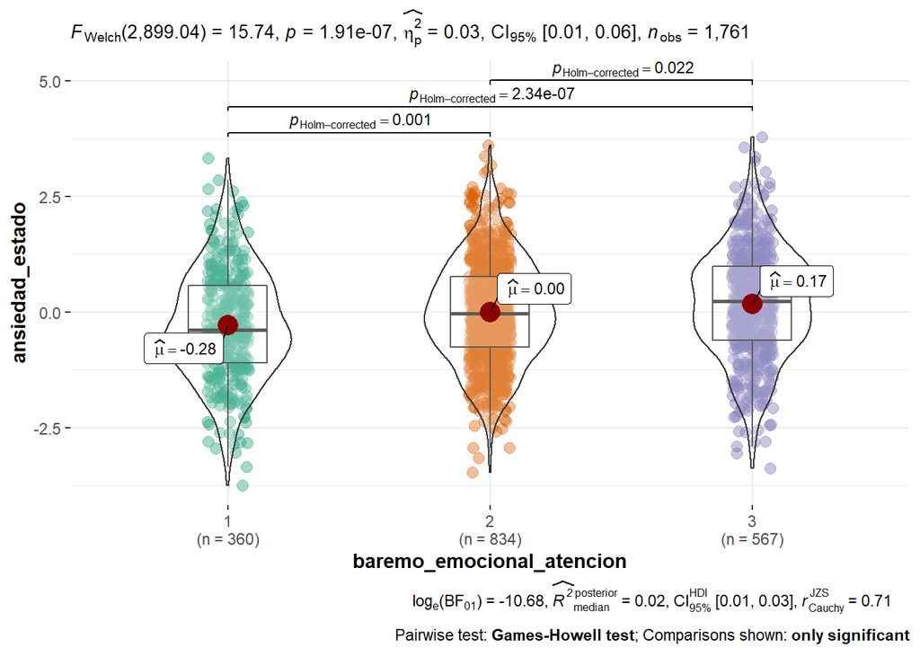

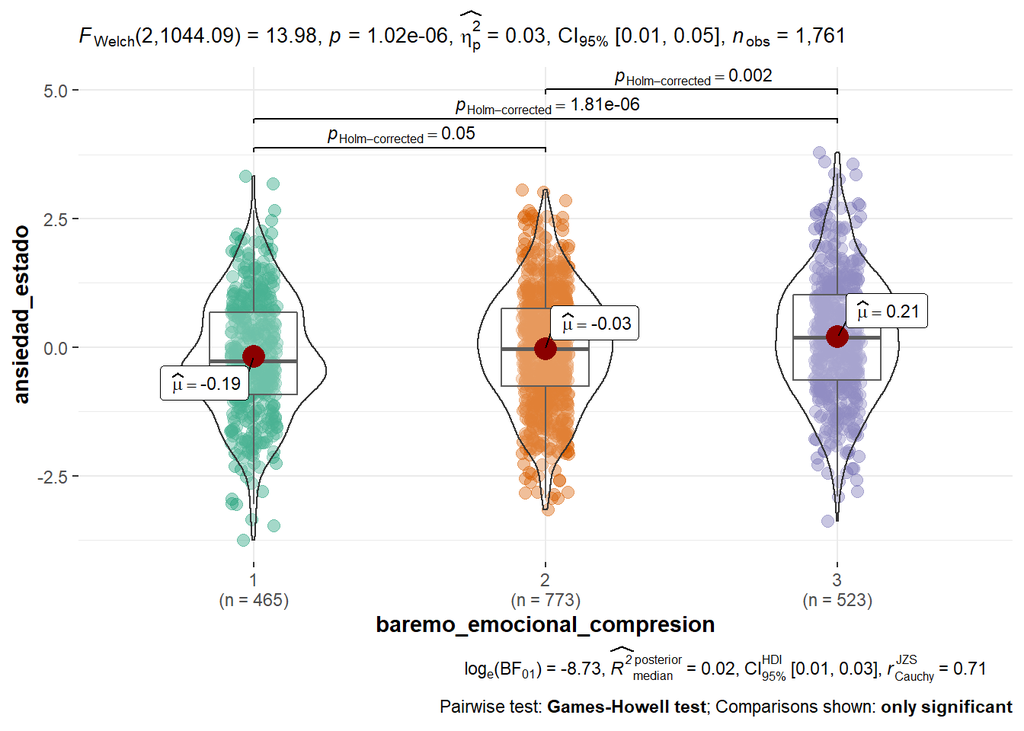

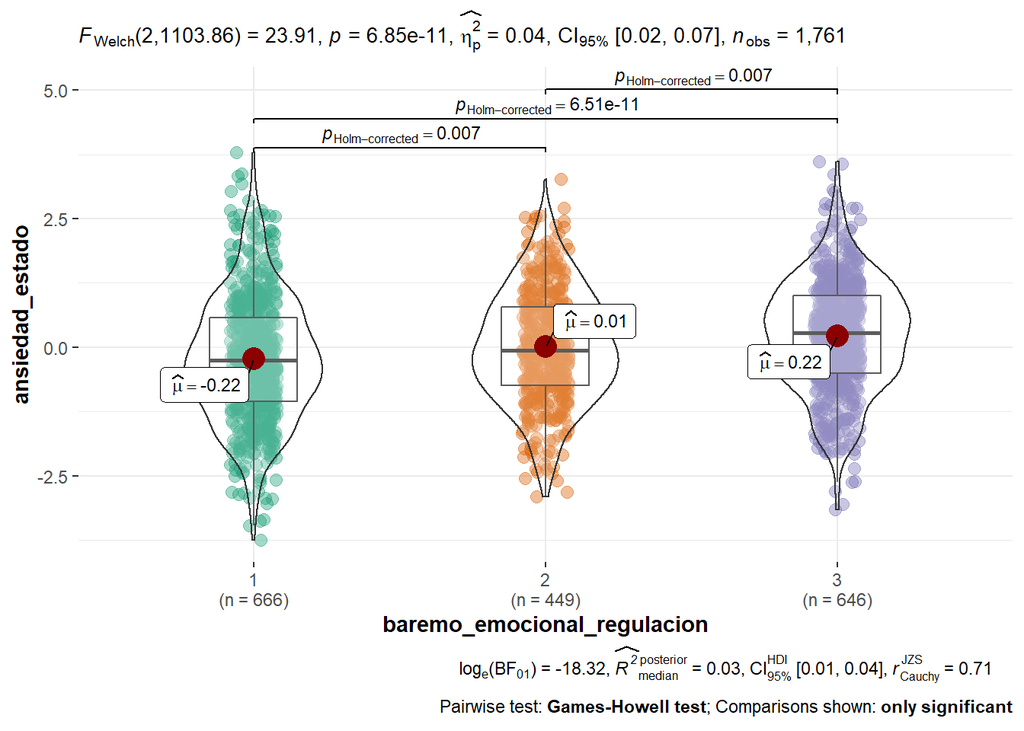

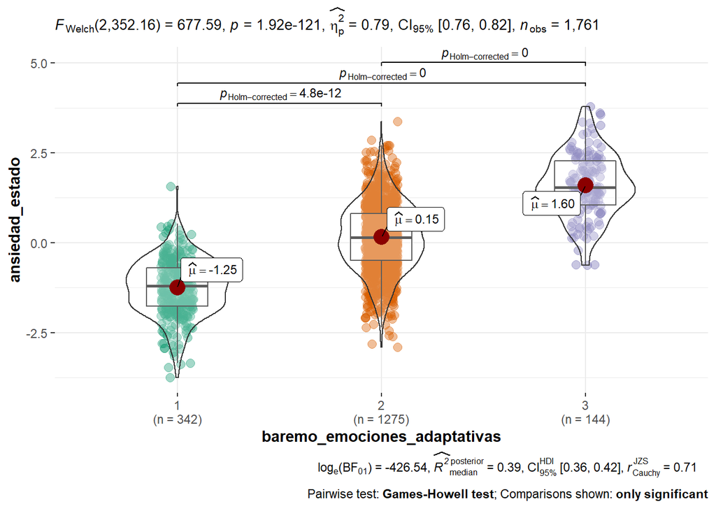

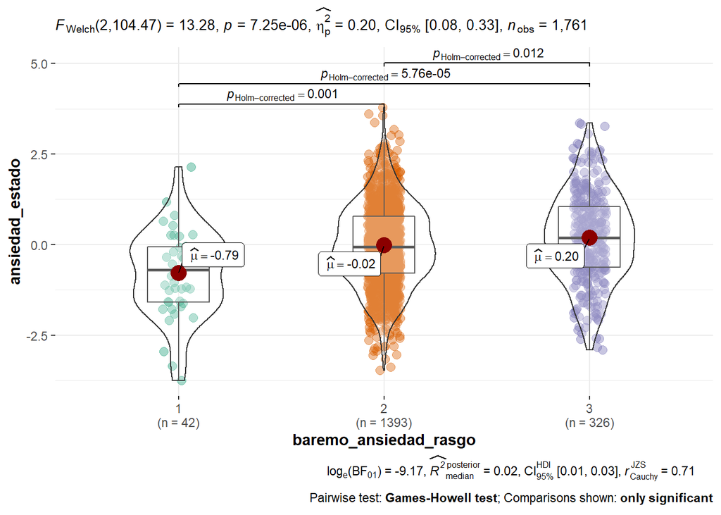

### Estado Civil

No utilizaría esta variable porque hay grupos muy pequeños (e.g. `viudo`) y la única diferencia estadísticamente significativa es entre los niveles `Soltero`y`Casado`. Los participantes solteros tuvieron en promedio mayor ansiedad que los sujetos casados con un 95% de confianza.

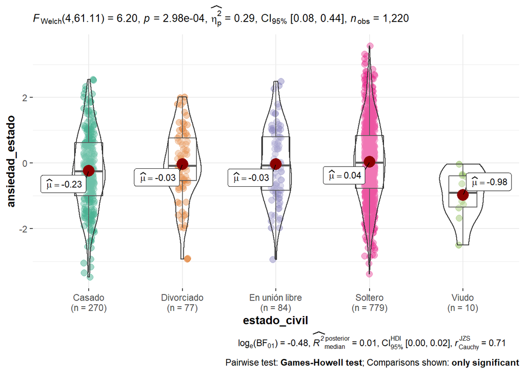

```r
# Estado civil
df_congreso_clean %>%
  ggbetweenstats(x = estado_civil, y = ansiedad_estado, effsize.type = "eta")
```

```r
aov_ansiedad_estcivil <- aov(ansiedad_estado ~ estado_civil, data = df_congreso_clean)

aov_ansiedad_estcivil %>% summary()
```

```
##                Df Sum Sq Mean Sq F value  Pr(>F)
## estado_civil    4   23.1   5.784   4.225 0.00211 **
## Residuals    1215 1663.2   1.369
## ---
## Signif. codes:  0 '***' 0.001 '**' 0.01 '*' 0.05 '.' 0.1 ' ' 1
## 541 observations deleted due to missingness
```

```r
aov_ansiedad_estcivil %>% TukeyHSD()
```

```
##   Tukey multiple comparisons of means
##     95% family-wise confidence level
##
## Fit: aov(formula = ansiedad_estado ~ estado_civil, data = df_congreso_clean)
##
## $estado_civil
##                                   diff         lwr         upr     p adj
## Divorciado-Casado          0.202526059 -0.21041121 0.615463332 0.6662769
## En unión libre-Casado      0.196766013 -0.20255917 0.596091195 0.6623043
## Soltero-Casado             0.266779967  0.04105285 0.492507079 0.0111643
## Viudo-Casado              -0.747096146 -1.77640030 0.282208010 0.2749443
## En unión libre-Divorciado -0.005760047 -0.51004328 0.498523182 0.9999998
## Soltero-Divorciado         0.064253908 -0.31757551 0.446083324 0.9908118
## Viudo-Divorciado          -0.949622205 -2.02400948 0.124765071 0.1120397
## Soltero-En unión libre     0.070013954 -0.29705159 0.437079497 0.9852478
## Viudo-En unión libre      -0.943862159 -2.01309152 0.125367203 0.1128503
## Viudo-Soltero             -1.013876113 -2.03109957 0.003347341 0.0512411
```

### Situación económica percepción

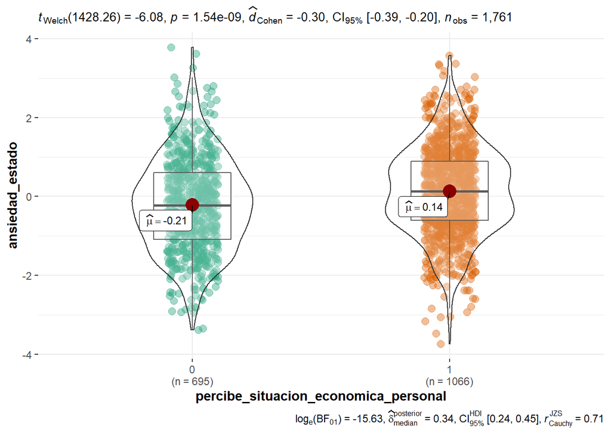

```r
df_congreso_clean %>%
  ggbetweenstats(x = percibe_situacion_economica_personal, y = ansiedad_estado, effsize.type = "eta")
```

```r
aov_ansiedad_siteconomica <- t.test(ansiedad_estado ~ percibe_situacion_economica_personal, data = df_congreso_clean)

aov_ansiedad_siteconomica
```

```
##
##  Welch Two Sample t-test
##
## data:  ansiedad_estado by percibe_situacion_economica_personal
## t = -6.0802, df = 1428.3, p-value = 1.538e-09
## alternative hypothesis: true difference in means is not equal to 0
## 95 percent confidence interval:
##  -0.4575431 -0.2343277
## sample estimates:
## mean in group 0 mean in group 1
##      -0.2094078       0.1365276
```

### Regresión Lineal

TODO: Hay demasiada multicolinearidad en el modelo.

```r
df_congreso_modelling <- df_congreso_clean %>%
  select(
    -nombre,
    -apellido,
    -starts_with("baremo_ansiedad"),
    -ansiedad_rasgo
  )


# lm_ansiedad_all <- lm(ansiedad_estado ~ ., data = df_congreso_modelling)

# car::vif(lm_ansiedad_all)
```